# Risk Factor Analysis

## Outcome Variable

**Outcome Variable:** swasted

## Predictor Variables

**Intervention Variable:** enstunt

**Adjustment Set:**

- arm
- sex
- W_mage
- meducyrs
- feducyrs
- vagbrth
- single
- brthmon
- W_parity
- delta_W_mage
- delta_meducyrs
- delta_feducyrs
- delta_vagbrth
- delta_single
- delta_brthmon
- delta_W_parity

## Stratifying Variables

The analysis was stratified on these variable(s):

- agecat
- studyid
- country

## Data Summary

| agecat | studyid | country | enstunt | swasted | n_cell | n |
| --- | --- | --- | --- | --- | --- | --- |
| Birth | ki0047075b-MAL-ED | BANGLADESH | 0 | 0 | 202 | 241 |
| Birth | ki0047075b-MAL-ED | BANGLADESH | 0 | 1 | 8 | 241 |
| Birth | ki0047075b-MAL-ED | BANGLADESH | 1 | 0 | 31 | 241 |
| Birth | ki0047075b-MAL-ED | BANGLADESH | 1 | 1 | 0 | 241 |
| Birth | ki0047075b-MAL-ED | BRAZIL | 0 | 0 | 169 | 183 |
| Birth | ki0047075b-MAL-ED | BRAZIL | 0 | 1 | 0 | 183 |
| Birth | ki0047075b-MAL-ED | BRAZIL | 1 | 0 | 14 | 183 |
| Birth | ki0047075b-MAL-ED | BRAZIL | 1 | 1 | 0 | 183 |
| Birth | ki0047075b-MAL-ED | INDIA | 0 | 0 | 168 | 203 |
| Birth | ki0047075b-MAL-ED | INDIA | 0 | 1 | 5 | 203 |
| Birth | ki0047075b-MAL-ED | INDIA | 1 | 0 | 28 | 203 |
| Birth | ki0047075b-MAL-ED | INDIA | 1 | 1 | 2 | 203 |
| Birth | ki0047075b-MAL-ED | NEPAL | 0 | 0 | 150 | 168 |
| Birth | ki0047075b-MAL-ED | NEPAL | 0 | 1 | 4 | 168 |
| Birth | ki0047075b-MAL-ED | NEPAL | 1 | 0 | 14 | 168 |
| Birth | ki0047075b-MAL-ED | NEPAL | 1 | 1 | 0 | 168 |
| Birth | ki0047075b-MAL-ED | PERU | 0 | 0 | 253 | 279 |
| Birth | ki0047075b-MAL-ED | PERU | 0 | 1 | 0 | 279 |
| Birth | ki0047075b-MAL-ED | PERU | 1 | 0 | 26 | 279 |
| Birth | ki0047075b-MAL-ED | PERU | 1 | 1 | 0 | 279 |
| Birth | ki0047075b-MAL-ED | SOUTH AFRICA | 0 | 0 | 230 | 258 |
| Birth | ki0047075b-MAL-ED | SOUTH AFRICA | 0 | 1 | 2 | 258 |
| Birth | ki0047075b-MAL-ED | SOUTH AFRICA | 1 | 0 | 26 | 258 |
| Birth | ki0047075b-MAL-ED | SOUTH AFRICA | 1 | 1 | 0 | 258 |
| Birth | ki0047075b-MAL-ED | TANZANIA, UNITED REPUBLIC OF | 0 | 0 | 104 | 118 |
| Birth | ki0047075b-MAL-ED | TANZANIA, UNITED REPUBLIC OF | 0 | 1 | 1 | 118 |
| Birth | ki0047075b-MAL-ED | TANZANIA, UNITED REPUBLIC OF | 1 | 0 | 13 | 118 |
| Birth | ki0047075b-MAL-ED | TANZANIA, UNITED REPUBLIC OF | 1 | 1 | 0 | 118 |
| Birth | ki1000108-CMC-V-BCS-2002 | INDIA | 0 | 0 | 73 | 88 |
| Birth | ki1000108-CMC-V-BCS-2002 | INDIA | 0 | 1 | 4 | 88 |

[output cut: 314 more lines]

The following strata were considered:

- agecat: 24 months, studyid: ki0047075b-MAL-ED, country: BANGLADESH
- agecat: 24 months, studyid: ki0047075b-MAL-ED, country: BRAZIL
- agecat: 24 months, studyid: ki0047075b-MAL-ED, country: INDIA
- agecat: 24 months, studyid: ki0047075b-MAL-ED, country: NEPAL
- agecat: 24 months, studyid: ki0047075b-MAL-ED, country: PERU
- agecat: 24 months, studyid: ki0047075b-MAL-ED, country: SOUTH AFRICA
- agecat: 24 months, studyid: ki0047075b-MAL-ED, country: TANZANIA, UNITED REPUBLIC OF
- agecat: 24 months, studyid: ki1000108-CMC-V-BCS-2002, country: INDIA
- agecat: 24 months, studyid: ki1000108-IRC, country: INDIA
- agecat: 24 months, studyid: ki1017093-NIH-Birth, country: BANGLADESH
- agecat: 24 months, studyid: ki1017093b-PROVIDE, country: BANGLADESH
- agecat: 24 months, studyid: ki1017093c-NIH-Crypto, country: BANGLADESH
- agecat: 24 months, studyid: ki1066203-TanzaniaChild2, country: TANZANIA, UNITED REPUBLIC OF
- agecat: 24 months, studyid: ki1101329-Keneba, country: GAMBIA
- agecat: 24 months, studyid: ki1113344-GMS-Nepal, country: NEPAL
- agecat: 24 months, studyid: ki1114097-CMIN, country: BANGLADESH
- agecat: 24 months, studyid: ki1114097-CMIN, country: GUINEA-BISSAU
- agecat: 24 months, studyid: ki1114097-CMIN, country: PERU
- agecat: 24 months, studyid: ki1114097-CONTENT, country: PERU
- agecat: 24 months, studyid: ki1119695-PROBIT, country: BELARUS
- agecat: 24 months, studyid: ki1126311-ZVITAMBO, country: ZIMBABWE
- agecat: 24 months, studyid: ki1135781-COHORTS, country: GUATEMALA
- agecat: 24 months, studyid: ki1135781-COHORTS, country: INDIA
- agecat: 24 months, studyid: ki1135781-COHORTS, country: PHILIPPINES
- agecat: 24 months, studyid: ki1148112-LCNI-5, country: MALAWI
- agecat: 24 months, studyid: kiGH5241-JiVitA-3, country: BANGLADESH
- agecat: 24 months, studyid: kiGH5241-JiVitA-4, country: BANGLADESH
- agecat: 6 months, studyid: ki0047075b-MAL-ED, country: BANGLADESH
- agecat: 6 months, studyid: ki0047075b-MAL-ED, country: BRAZIL
- agecat: 6 months, studyid: ki0047075b-MAL-ED, country: INDIA
- agecat: 6 months, studyid: ki0047075b-MAL-ED, country: NEPAL
- agecat: 6 months, studyid: ki0047075b-MAL-ED, country: PERU
- agecat: 6 months, studyid: ki0047075b-MAL-ED, country: SOUTH AFRICA
- agecat: 6 months, studyid: ki0047075b-MAL-ED, country: TANZANIA, UNITED REPUBLIC OF
- agecat: 6 months, studyid: ki1000108-CMC-V-BCS-2002, country: INDIA
- agecat: 6 months, studyid: ki1000108-IRC, country: INDIA
- agecat: 6 months, studyid: ki1000109-EE, country: PAKISTAN
- agecat: 6 months, studyid: ki1000109-ResPak, country: PAKISTAN
- agecat: 6 months, studyid: ki1000304b-SAS-CompFeed, country: INDIA
- agecat: 6 months, studyid: ki1000304b-SAS-FoodSuppl, country: INDIA
- agecat: 6 months, studyid: ki1017093-NIH-Birth, country: BANGLADESH
- agecat: 6 months, studyid: ki1017093b-PROVIDE, country: BANGLADESH
- agecat: 6 months, studyid: ki1017093c-NIH-Crypto, country: BANGLADESH
- agecat: 6 months, studyid: ki1066203-TanzaniaChild2, country: TANZANIA, UNITED REPUBLIC OF
- agecat: 6 months, studyid: ki1101329-Keneba, country: GAMBIA
- agecat: 6 months, studyid: ki1112895-Guatemala BSC, country: GUATEMALA
- agecat: 6 months, studyid: ki1113344-GMS-Nepal, country: NEPAL
- agecat: 6 months, studyid: ki1114097-CMIN, country: BANGLADESH
- agecat: 6 months, studyid: ki1114097-CMIN, country: BRAZIL
- agecat: 6 months, studyid: ki1114097-CMIN, country: GUINEA-BISSAU
- agecat: 6 months, studyid: ki1114097-CMIN, country: PERU
- agecat: 6 months, studyid: ki1114097-CONTENT, country: PERU
- agecat: 6 months, studyid: ki1119695-PROBIT, country: BELARUS
- agecat: 6 months, studyid: ki1126311-ZVITAMBO, country: ZIMBABWE
- agecat: 6 months, studyid: ki1135781-COHORTS, country: GUATEMALA
- agecat: 6 months, studyid: ki1135781-COHORTS, country: INDIA
- agecat: 6 months, studyid: ki1135781-COHORTS, country: PHILIPPINES
- agecat: 6 months, studyid: ki1148112-LCNI-5, country: MALAWI
- agecat: 6 months, studyid: kiGH5241-JiVitA-3, country: BANGLADESH
- agecat: 6 months, studyid: kiGH5241-JiVitA-4, country: BANGLADESH
- agecat: Birth, studyid: ki0047075b-MAL-ED, country: BANGLADESH
- agecat: Birth, studyid: ki0047075b-MAL-ED, country: BRAZIL
- agecat: Birth, studyid: ki0047075b-MAL-ED, country: INDIA
- agecat: Birth, studyid: ki0047075b-MAL-ED, country: NEPAL
- agecat: Birth, studyid: ki0047075b-MAL-ED, country: PERU
- agecat: Birth, studyid: ki0047075b-MAL-ED, country: SOUTH AFRICA
- agecat: Birth, studyid: ki0047075b-MAL-ED, country: TANZANIA, UNITED REPUBLIC OF
- agecat: Birth, studyid: ki1000108-CMC-V-BCS-2002, country: INDIA
- agecat: Birth, studyid: ki1000108-IRC, country: INDIA
- agecat: Birth, studyid: ki1000109-EE, country: PAKISTAN
- agecat: Birth, studyid: ki1000109-ResPak, country: PAKISTAN
- agecat: Birth, studyid: ki1000304b-SAS-CompFeed, country: INDIA
- agecat: Birth, studyid: ki1017093-NIH-Birth, country: BANGLADESH
- agecat: Birth, studyid: ki1017093c-NIH-Crypto, country: BANGLADESH
- agecat: Birth, studyid: ki1101329-Keneba, country: GAMBIA
- agecat: Birth, studyid: ki1114097-CMIN, country: BANGLADESH
- agecat: Birth, studyid: ki1114097-CMIN, country: BRAZIL
- agecat: Birth, studyid: ki1114097-CMIN, country: PERU
- agecat: Birth, studyid: ki1114097-CONTENT, country: PERU
- agecat: Birth, studyid: ki1119695-PROBIT, country: BELARUS
- agecat: Birth, studyid: ki1126311-ZVITAMBO, country: ZIMBABWE
- agecat: Birth, studyid: ki1135781-COHORTS, country: GUATEMALA
- agecat: Birth, studyid: ki1135781-COHORTS, country: INDIA
- agecat: Birth, studyid: ki1135781-COHORTS, country: PHILIPPINES
- agecat: Birth, studyid: kiGH5241-JiVitA-3, country: BANGLADESH
- agecat: Birth, studyid: kiGH5241-JiVitA-4, country: BANGLADESH

### Dropped Strata

Some strata were dropped due to rare outcomes:

- agecat: Birth, studyid: ki0047075b-MAL-ED, country: BANGLADESH
- agecat: Birth, studyid: ki0047075b-MAL-ED, country: BRAZIL
- agecat: Birth, studyid: ki0047075b-MAL-ED, country: INDIA
- agecat: Birth, studyid: ki0047075b-MAL-ED, country: NEPAL
- agecat: Birth, studyid: ki0047075b-MAL-ED, country: PERU
- agecat: Birth, studyid: ki0047075b-MAL-ED, country: SOUTH AFRICA
- agecat: Birth, studyid: ki0047075b-MAL-ED, country: TANZANIA, UNITED REPUBLIC OF
- agecat: Birth, studyid: ki1000108-CMC-V-BCS-2002, country: INDIA
- agecat: Birth, studyid: ki1000108-IRC, country: INDIA
- agecat: Birth, studyid: ki1000109-EE, country: PAKISTAN
- agecat: Birth, studyid: ki1000109-ResPak, country: PAKISTAN
- agecat: Birth, studyid: ki1000304b-SAS-CompFeed, country: INDIA
- agecat: Birth, studyid: ki1017093-NIH-Birth, country: BANGLADESH
- agecat: Birth, studyid: ki1017093c-NIH-Crypto, country: BANGLADESH
- agecat: Birth, studyid: ki1101329-Keneba, country: GAMBIA
- agecat: Birth, studyid: ki1114097-CMIN, country: BANGLADESH
- agecat: Birth, studyid: ki1114097-CMIN, country: BRAZIL
- agecat: Birth, studyid: ki1114097-CMIN, country: PERU
- agecat: Birth, studyid: ki1114097-CONTENT, country: PERU
- agecat: Birth, studyid: ki1119695-PROBIT, country: BELARUS
- agecat: Birth, studyid: ki1135781-COHORTS, country: GUATEMALA
- agecat: Birth, studyid: ki1135781-COHORTS, country: PHILIPPINES
- agecat: Birth, studyid: kiGH5241-JiVitA-4, country: BANGLADESH
- agecat: 6 months, studyid: ki0047075b-MAL-ED, country: BANGLADESH
- agecat: 6 months, studyid: ki0047075b-MAL-ED, country: BRAZIL
- agecat: 6 months, studyid: ki0047075b-MAL-ED, country: INDIA
- agecat: 6 months, studyid: ki0047075b-MAL-ED, country: NEPAL
- agecat: 6 months, studyid: ki0047075b-MAL-ED, country: PERU
- agecat: 6 months, studyid: ki0047075b-MAL-ED, country: SOUTH AFRICA
- agecat: 6 months, studyid: ki0047075b-MAL-ED, country: TANZANIA, UNITED REPUBLIC OF
- agecat: 6 months, studyid: ki1000108-CMC-V-BCS-2002, country: INDIA
- agecat: 6 months, studyid: ki1000108-IRC, country: INDIA
- agecat: 6 months, studyid: ki1000109-EE, country: PAKISTAN
- agecat: 6 months, studyid: ki1000109-ResPak, country: PAKISTAN
- agecat: 6 months, studyid: ki1017093-NIH-Birth, country: BANGLADESH
- agecat: 6 months, studyid: ki1017093b-PROVIDE, country: BANGLADESH
- agecat: 6 months, studyid: ki1017093c-NIH-Crypto, country: BANGLADESH
- agecat: 6 months, studyid: ki1066203-TanzaniaChild2, country: TANZANIA, UNITED REPUBLIC OF
- agecat: 6 months, studyid: ki1112895-Guatemala BSC, country: GUATEMALA
- agecat: 6 months, studyid: ki1113344-GMS-Nepal, country: NEPAL
- agecat: 6 months, studyid: ki1114097-CMIN, country: BANGLADESH
- agecat: 6 months, studyid: ki1114097-CMIN, country: BRAZIL
- agecat: 6 months, studyid: ki1114097-CMIN, country: GUINEA-BISSAU
- agecat: 6 months, studyid: ki1114097-CMIN, country: PERU
- agecat: 6 months, studyid: ki1114097-CONTENT, country: PERU
- agecat: 6 months, studyid: ki1119695-PROBIT, country: BELARUS
- agecat: 6 months, studyid: ki1135781-COHORTS, country: GUATEMALA
- agecat: 6 months, studyid: ki1135781-COHORTS, country: PHILIPPINES
- agecat: 6 months, studyid: ki1148112-LCNI-5, country: MALAWI
- agecat: 24 months, studyid: ki0047075b-MAL-ED, country: BANGLADESH
- agecat: 24 months, studyid: ki0047075b-MAL-ED, country: BRAZIL
- agecat: 24 months, studyid: ki0047075b-MAL-ED, country: INDIA
- agecat: 24 months, studyid: ki0047075b-MAL-ED, country: NEPAL
- agecat: 24 months, studyid: ki0047075b-MAL-ED, country: PERU
- agecat: 24 months, studyid: ki0047075b-MAL-ED, country: SOUTH AFRICA
- agecat: 24 months, studyid: ki0047075b-MAL-ED, country: TANZANIA, UNITED REPUBLIC OF
- agecat: 24 months, studyid: ki1000108-CMC-V-BCS-2002, country: INDIA
- agecat: 24 months, studyid: ki1000108-IRC, country: INDIA
- agecat: 24 months, studyid: ki1017093-NIH-Birth, country: BANGLADESH
- agecat: 24 months, studyid: ki1017093b-PROVIDE, country: BANGLADESH
- agecat: 24 months, studyid: ki1017093c-NIH-Crypto, country: BANGLADESH
- agecat: 24 months, studyid: ki1066203-TanzaniaChild2, country: TANZANIA, UNITED REPUBLIC OF
- agecat: 24 months, studyid: ki1101329-Keneba, country: GAMBIA
- agecat: 24 months, studyid: ki1113344-GMS-Nepal, country: NEPAL
- agecat: 24 months, studyid: ki1114097-CMIN, country: BANGLADESH
- agecat: 24 months, studyid: ki1114097-CMIN, country: GUINEA-BISSAU
- agecat: 24 months, studyid: ki1114097-CMIN, country: PERU
- agecat: 24 months, studyid: ki1114097-CONTENT, country: PERU
- agecat: 24 months, studyid: ki1119695-PROBIT, country: BELARUS
- agecat: 24 months, studyid: ki1135781-COHORTS, country: GUATEMALA
- agecat: 24 months, studyid: ki1135781-COHORTS, country: PHILIPPINES
- agecat: 24 months, studyid: ki1148112-LCNI-5, country: MALAWI

## Methods Detail

We’re interested in the causal parameters $E[Y_a]$ for all values of $a \in \mathcal{A}$. These parameters represent the mean outcome if, possibly contrary to fact, we intervened to set all units to have $A=a$. Under the randomization and positivity assumptions, these are identified by the statistical parameters $\psi_a=E_W[E_{Y|A,W}(Y|A=a,W)]$. In addition, we’re interested in the mean of $Y$, $E[Y]$ under no intervention (the observed mean). We will estimate these parameters by using SuperLearner to fit the relevant likelihood factors – $E_{Y|A,W}(Y|A=a,W)$ and $p(A=a|W)$, and then updating our likelihood fit using a joint TMLE.

For unadjusted analyses ($W=\{\}$), initial likelihoods were estimated using Lrnr_glm to estimate the simple $E(Y|A)$ and Lrnr_mean to estimate $p(A)$. For adjusted analyses, a small library containing Lrnr_glmnet, Lrnr_xgboost, and Lrnr_mean was used.

Having estimated these parameters, we will then use the delta method to estimate relative risks and attributable risks relative to a prespecified baseline level of $A$.

# Results Detail

## Results Plots

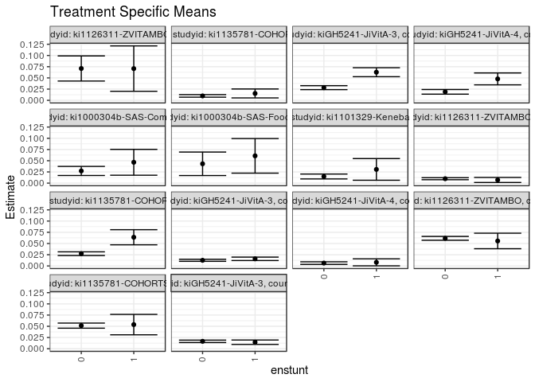

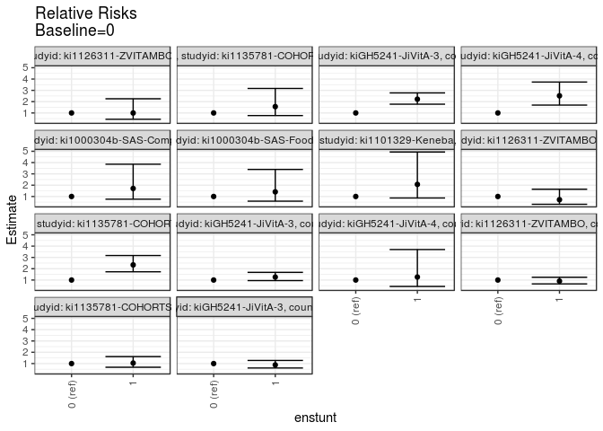

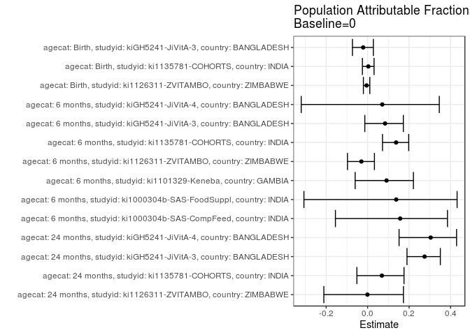

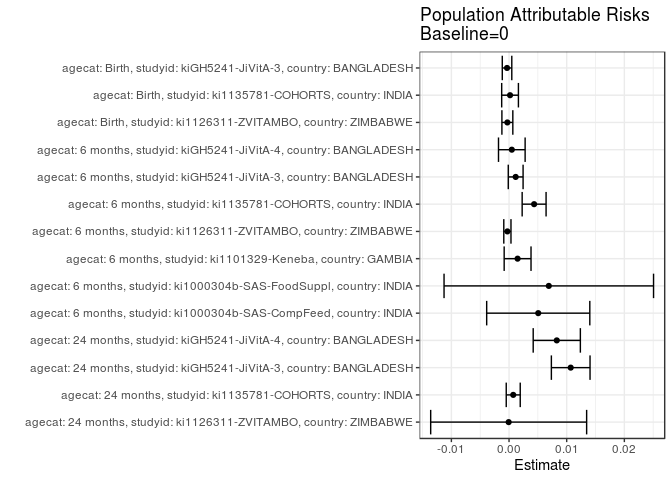

## Results Table

### Parameter: TSM

| agecat | studyid | country | intervention_level | baseline_level | estimate | ci_lower | ci_upper |
| --- | --- | --- | --- | --- | --- | --- | --- |
| Birth | ki1126311-ZVITAMBO | ZIMBABWE | 0 | NA | 0.0615320 | 0.0572729 | 0.0657911 |
| Birth | ki1126311-ZVITAMBO | ZIMBABWE | 1 | NA | 0.0556395 | 0.0383615 | 0.0729175 |
| Birth | ki1135781-COHORTS | INDIA | 0 | NA | 0.0514947 | 0.0458142 | 0.0571753 |
| Birth | ki1135781-COHORTS | INDIA | 1 | NA | 0.0538085 | 0.0310498 | 0.0765673 |
| Birth | kiGH5241-JiVitA-3 | BANGLADESH | 0 | NA | 0.0165156 | 0.0138439 | 0.0191873 |
| Birth | kiGH5241-JiVitA-3 | BANGLADESH | 1 | NA | 0.0145469 | 0.0096128 | 0.0194809 |
| 6 months | ki1000304b-SAS-CompFeed | INDIA | 0 | NA | 0.0271683 | 0.0170821 | 0.0372546 |
| 6 months | ki1000304b-SAS-CompFeed | INDIA | 1 | NA | 0.0464901 | 0.0176742 | 0.0753061 |
| 6 months | ki1000304b-SAS-FoodSuppl | INDIA | 0 | NA | 0.0431035 | 0.0169358 | 0.0692711 |
| 6 months | ki1000304b-SAS-FoodSuppl | INDIA | 1 | NA | 0.0608108 | 0.0222580 | 0.0993636 |
| 6 months | ki1101329-Keneba | GAMBIA | 0 | NA | 0.0147913 | 0.0093520 | 0.0202307 |
| 6 months | ki1101329-Keneba | GAMBIA | 1 | NA | 0.0306122 | 0.0064899 | 0.0547346 |
| 6 months | ki1126311-ZVITAMBO | ZIMBABWE | 0 | NA | 0.0098462 | 0.0075986 | 0.0120939 |
| 6 months | ki1126311-ZVITAMBO | ZIMBABWE | 1 | NA | 0.0070588 | 0.0014303 | 0.0126873 |
| 6 months | ki1135781-COHORTS | INDIA | 0 | NA | 0.0273287 | 0.0232131 | 0.0314442 |
| 6 months | ki1135781-COHORTS | INDIA | 1 | NA | 0.0639229 | 0.0470764 | 0.0807695 |
| 6 months | kiGH5241-JiVitA-3 | BANGLADESH | 0 | NA | 0.0125514 | 0.0102816 | 0.0148212 |
| 6 months | kiGH5241-JiVitA-3 | BANGLADESH | 1 | NA | 0.0158345 | 0.0120122 | 0.0196569 |
| 6 months | kiGH5241-JiVitA-4 | BANGLADESH | 0 | NA | 0.0063463 | 0.0034816 | 0.0092109 |
| 6 months | kiGH5241-JiVitA-4 | BANGLADESH | 1 | NA | 0.0080285 | 0.0002496 | 0.0158074 |
| 24 months | ki1126311-ZVITAMBO | ZIMBABWE | 0 | NA | 0.0709877 | 0.0429919 | 0.0989834 |
| 24 months | ki1126311-ZVITAMBO | ZIMBABWE | 1 | NA | 0.0707071 | 0.0201535 | 0.1212607 |
| 24 months | ki1135781-COHORTS | INDIA | 0 | NA | 0.0098553 | 0.0070160 | 0.0126947 |
| 24 months | ki1135781-COHORTS | INDIA | 1 | NA | 0.0153666 | 0.0054193 | 0.0253139 |
| 24 months | kiGH5241-JiVitA-3 | BANGLADESH | 0 | NA | 0.0282443 | 0.0238407 | 0.0326479 |
| 24 months | kiGH5241-JiVitA-3 | BANGLADESH | 1 | NA | 0.0626513 | 0.0526595 | 0.0726430 |
| 24 months | kiGH5241-JiVitA-4 | BANGLADESH | 0 | NA | 0.0189631 | 0.0137773 | 0.0241489 |
| 24 months | kiGH5241-JiVitA-4 | BANGLADESH | 1 | NA | 0.0477349 | 0.0344552 | 0.0610146 |

### Parameter: E(Y)

| agecat | studyid | country | intervention_level | baseline_level | estimate | ci_lower | ci_upper |
| --- | --- | --- | --- | --- | --- | --- | --- |
| Birth | ki1126311-ZVITAMBO | ZIMBABWE | NA | NA | 0.0612419 | 0.0571066 | 0.0653771 |
| Birth | ki1135781-COHORTS | INDIA | NA | NA | 0.0516712 | 0.0461576 | 0.0571849 |
| Birth | kiGH5241-JiVitA-3 | BANGLADESH | NA | NA | 0.0161691 | 0.0138058 | 0.0185324 |
| 6 months | ki1000304b-SAS-CompFeed | INDIA | NA | NA | 0.0322339 | 0.0235219 | 0.0409459 |
| 6 months | ki1000304b-SAS-FoodSuppl | INDIA | NA | NA | 0.0500000 | 0.0280580 | 0.0719420 |
| 6 months | ki1101329-Keneba | GAMBIA | NA | NA | 0.0162757 | 0.0108484 | 0.0217031 |
| 6 months | ki1126311-ZVITAMBO | ZIMBABWE | NA | NA | 0.0095595 | 0.0074615 | 0.0116576 |
| 6 months | ki1135781-COHORTS | INDIA | NA | NA | 0.0316788 | 0.0275309 | 0.0358267 |
| 6 months | kiGH5241-JiVitA-3 | BANGLADESH | NA | NA | 0.0137035 | 0.0116269 | 0.0157801 |
| 6 months | kiGH5241-JiVitA-4 | BANGLADESH | NA | NA | 0.0068281 | 0.0038634 | 0.0097927 |
| 24 months | ki1126311-ZVITAMBO | ZIMBABWE | NA | NA | 0.0709220 | 0.0464309 | 0.0954131 |
| 24 months | ki1135781-COHORTS | INDIA | NA | NA | 0.0105840 | 0.0078264 | 0.0133416 |
| 24 months | kiGH5241-JiVitA-3 | BANGLADESH | NA | NA | 0.0389399 | 0.0346167 | 0.0432631 |
| 24 months | kiGH5241-JiVitA-4 | BANGLADESH | NA | NA | 0.0272439 | 0.0220352 | 0.0324527 |

### Parameter: RR

| agecat | studyid | country | intervention_level | baseline_level | estimate | ci_lower | ci_upper |
| --- | --- | --- | --- | --- | --- | --- | --- |
| Birth | ki1126311-ZVITAMBO | ZIMBABWE | 0 | 0 | 1.0000000 | 1.0000000 | 1.000000 |
| Birth | ki1126311-ZVITAMBO | ZIMBABWE | 1 | 0 | 0.9042365 | 0.6578363 | 1.242929 |
| Birth | ki1135781-COHORTS | INDIA | 0 | 0 | 1.0000000 | 1.0000000 | 1.000000 |
| Birth | ki1135781-COHORTS | INDIA | 1 | 0 | 1.0449332 | 0.6749632 | 1.617696 |
| Birth | kiGH5241-JiVitA-3 | BANGLADESH | 0 | 0 | 1.0000000 | 1.0000000 | 1.000000 |
| Birth | kiGH5241-JiVitA-3 | BANGLADESH | 1 | 0 | 0.8807967 | 0.6087691 | 1.274379 |
| 6 months | ki1000304b-SAS-CompFeed | INDIA | 0 | 0 | 1.0000000 | 1.0000000 | 1.000000 |
| 6 months | ki1000304b-SAS-CompFeed | INDIA | 1 | 0 | 1.7111869 | 0.7594696 | 3.855534 |
| 6 months | ki1000304b-SAS-FoodSuppl | INDIA | 0 | 0 | 1.0000000 | 1.0000000 | 1.000000 |
| 6 months | ki1000304b-SAS-FoodSuppl | INDIA | 1 | 0 | 1.4108107 | 0.5864838 | 3.393763 |
| 6 months | ki1101329-Keneba | GAMBIA | 0 | 0 | 1.0000000 | 1.0000000 | 1.000000 |
| 6 months | ki1101329-Keneba | GAMBIA | 1 | 0 | 2.0696064 | 0.8674280 | 4.937898 |
| 6 months | ki1126311-ZVITAMBO | ZIMBABWE | 0 | 0 | 1.0000000 | 1.0000000 | 1.000000 |
| 6 months | ki1126311-ZVITAMBO | ZIMBABWE | 1 | 0 | 0.7169057 | 0.3127925 | 1.643114 |
| 6 months | ki1135781-COHORTS | INDIA | 0 | 0 | 1.0000000 | 1.0000000 | 1.000000 |
| 6 months | ki1135781-COHORTS | INDIA | 1 | 0 | 2.3390420 | 1.7267150 | 3.168512 |
| 6 months | kiGH5241-JiVitA-3 | BANGLADESH | 0 | 0 | 1.0000000 | 1.0000000 | 1.000000 |
| 6 months | kiGH5241-JiVitA-3 | BANGLADESH | 1 | 0 | 1.2615725 | 0.9488031 | 1.677445 |
| 6 months | kiGH5241-JiVitA-4 | BANGLADESH | 0 | 0 | 1.0000000 | 1.0000000 | 1.000000 |
| 6 months | kiGH5241-JiVitA-4 | BANGLADESH | 1 | 0 | 1.2650803 | 0.4328456 | 3.697458 |
| 24 months | ki1126311-ZVITAMBO | ZIMBABWE | 0 | 0 | 1.0000000 | 1.0000000 | 1.000000 |
| 24 months | ki1126311-ZVITAMBO | ZIMBABWE | 1 | 0 | 0.9960474 | 0.4402169 | 2.253686 |
| 24 months | ki1135781-COHORTS | INDIA | 0 | 0 | 1.0000000 | 1.0000000 | 1.000000 |
| 24 months | ki1135781-COHORTS | INDIA | 1 | 0 | 1.5592153 | 0.7676296 | 3.167091 |
| 24 months | kiGH5241-JiVitA-3 | BANGLADESH | 0 | 0 | 1.0000000 | 1.0000000 | 1.000000 |
| 24 months | kiGH5241-JiVitA-3 | BANGLADESH | 1 | 0 | 2.2181926 | 1.7744582 | 2.772890 |
| 24 months | kiGH5241-JiVitA-4 | BANGLADESH | 0 | 0 | 1.0000000 | 1.0000000 | 1.000000 |
| 24 months | kiGH5241-JiVitA-4 | BANGLADESH | 1 | 0 | 2.5172527 | 1.6973974 | 3.733104 |

### Parameter: PAR

| agecat | studyid | country | intervention_level | baseline_level | estimate | ci_lower | ci_upper |
| --- | --- | --- | --- | --- | --- | --- | --- |
| Birth | ki1126311-ZVITAMBO | ZIMBABWE | 0 | NA | -0.0002901 | -0.0012376 | 0.0006573 |
| Birth | ki1135781-COHORTS | INDIA | 0 | NA | 0.0001765 | -0.0012742 | 0.0016272 |
| Birth | kiGH5241-JiVitA-3 | BANGLADESH | 0 | NA | -0.0003465 | -0.0011714 | 0.0004784 |
| 6 months | ki1000304b-SAS-CompFeed | INDIA | 0 | NA | 0.0050655 | -0.0038775 | 0.0140086 |
| 6 months | ki1000304b-SAS-FoodSuppl | INDIA | 0 | NA | 0.0068966 | -0.0112717 | 0.0250648 |
| 6 months | ki1101329-Keneba | GAMBIA | 0 | NA | 0.0014844 | -0.0008441 | 0.0038129 |
| 6 months | ki1126311-ZVITAMBO | ZIMBABWE | 0 | NA | -0.0002867 | -0.0009103 | 0.0003369 |
| 6 months | ki1135781-COHORTS | INDIA | 0 | NA | 0.0043502 | 0.0022756 | 0.0064247 |
| 6 months | kiGH5241-JiVitA-3 | BANGLADESH | 0 | NA | 0.0011521 | -0.0001330 | 0.0024372 |
| 6 months | kiGH5241-JiVitA-4 | BANGLADESH | 0 | NA | 0.0004818 | -0.0018272 | 0.0027908 |
| 24 months | ki1126311-ZVITAMBO | ZIMBABWE | 0 | NA | -0.0000657 | -0.0135905 | 0.0134591 |
| 24 months | ki1135781-COHORTS | INDIA | 0 | NA | 0.0007287 | -0.0004843 | 0.0019416 |
| 24 months | kiGH5241-JiVitA-3 | BANGLADESH | 0 | NA | 0.0106956 | 0.0073429 | 0.0140484 |
| 24 months | kiGH5241-JiVitA-4 | BANGLADESH | 0 | NA | 0.0082808 | 0.0041912 | 0.0123704 |

### Parameter: PAF

| agecat | studyid | country | intervention_level | baseline_level | estimate | ci_lower | ci_upper |
| --- | --- | --- | --- | --- | --- | --- | --- |
| Birth | ki1126311-ZVITAMBO | ZIMBABWE | 0 | NA | -0.0047376 | -0.0203252 | 0.0106120 |
| Birth | ki1135781-COHORTS | INDIA | 0 | NA | 0.0034165 | -0.0250555 | 0.0310976 |
| Birth | kiGH5241-JiVitA-3 | BANGLADESH | 0 | NA | -0.0214311 | -0.0731047 | 0.0277543 |
| 6 months | ki1000304b-SAS-CompFeed | INDIA | 0 | NA | 0.1571494 | -0.1551812 | 0.3850341 |
| 6 months | ki1000304b-SAS-FoodSuppl | INDIA | 0 | NA | 0.1379310 | -0.3069960 | 0.4313962 |
| 6 months | ki1101329-Keneba | GAMBIA | 0 | NA | 0.0912029 | -0.0600361 | 0.2208641 |
| 6 months | ki1126311-ZVITAMBO | ZIMBABWE | 0 | NA | -0.0299912 | -0.0969920 | 0.0329175 |
| 6 months | ki1135781-COHORTS | INDIA | 0 | NA | 0.1373205 | 0.0718164 | 0.1982019 |
| 6 months | kiGH5241-JiVitA-3 | BANGLADESH | 0 | NA | 0.0840725 | -0.0134827 | 0.1722373 |
| 6 months | kiGH5241-JiVitA-4 | BANGLADESH | 0 | NA | 0.0705628 | -0.3200587 | 0.3455946 |
| 24 months | ki1126311-ZVITAMBO | ZIMBABWE | 0 | NA | -0.0009259 | -0.2110026 | 0.1727081 |
| 24 months | ki1135781-COHORTS | INDIA | 0 | NA | 0.0688456 | -0.0516105 | 0.1755041 |
| 24 months | kiGH5241-JiVitA-3 | BANGLADESH | 0 | NA | 0.2746697 | 0.1898531 | 0.3506067 |
| 24 months | kiGH5241-JiVitA-4 | BANGLADESH | 0 | NA | 0.3039517 | 0.1516769 | 0.4288930 |